# Regression Analysis

# Tidying the data

## Data cleaning for regression analysis

We are interested in whether there is a linear association between suicide rate and some factors. From the `us_2017` dataset, we choose `suicide` as the mean outcome, `gun`, `alcohol`, `temperature`, `precipitation`, `marijuana`, `education`, `gdp` and `gender` as candidate covariates, each with 50 observations.

One value of `gun` in Wyoming and one value of `temperature` in Rhode Island were missing. We replaced them with the mean value of other 49 observations.

After tidying the `us_2017` dataset, we obtain the `regression_data` dataset. The description of `regression_data` is shown below:

| Variables | Description |
| --- | --- |
| state | State |
| suicide | Suicide rate per 100000 population |
| gun | Number of guns per 1000 population |
| alcohol | Alcohol consumption per capita (gallons of ethanol) |
| temperature | Average temperature (F) |
| precipitation | Average precipitation (inches) |
| marijuana | Marijuana use in adults (%) |
| education | Educational attainment - bachelor’s degree or higher (%) |
| gdp | GDP per capita (dollars) |
| gender | Male (%) |

```r
regression_data = read_csv("../data/us_2017.csv") %>%
  janitor::clean_names() %>%
  filter(state != "District of Columbia") %>%
  mutate(
    suicide = suicide_rate,
    gun = guns_number_per_capita_average,
    alcohol = alcohol_consumption,
    marijuana = marijuana_usage * 100,
    education = (advanced_degree + bachelors_degree) * 100,
    gender = male_proportion * 100
    ) %>%
  select(state, suicide, gun, alcohol, temperature, precipitation, marijuana, education, gdp, gender) %>%
  # replace missing value with mean value
  mutate(
    gun = replace_na(gun, mean(gun, na.rm = TRUE)),
    temperature = replace_na(temperature, mean(temperature, na.rm = TRUE)))
```

# Regression Analysis

## Simple linear regression

First, we used scatter plot to see the relationship between suicide rate and each covariate. The scatter plots with linear regression line are shown below:

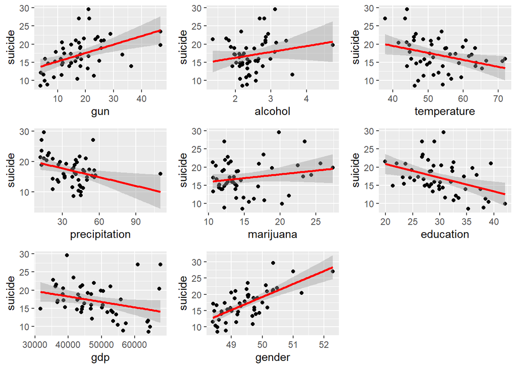

```r
# gun
gun_plot =
  regression_data %>%
  ggplot(aes(x = gun, y = suicide)) +
  geom_point() +
  geom_smooth(method = lm, color = "red",show.legend = FALSE, se = TRUE)

# alcohol
alcohol_plot =
  regression_data %>%
  ggplot(aes(x = alcohol, y = suicide)) +
  geom_point() +
  geom_smooth(method = lm, color = "red",show.legend = FALSE, se = TRUE)

# temperature
temp_plot =
  regression_data %>%
  ggplot(aes(x = temperature, y = suicide)) +
  geom_point() +
  geom_smooth(method = lm, color = "red",show.legend = FALSE, se = TRUE)

# precipitation
precip_plot =
  regression_data %>%
  ggplot(aes(x = precipitation, y = suicide)) +
  geom_point() +
  geom_smooth(method = lm, color = "red",show.legend = FALSE, se = TRUE)

# marijuana
mari_plot =
  regression_data %>%
  ggplot(aes(x = marijuana, y = suicide)) +
  geom_point() +
  geom_smooth(method = lm, color = "red",show.legend = FALSE, se = TRUE)

# education
edu_plot =
  regression_data %>%
  ggplot(aes(x = education, y = suicide)) +
  geom_point() +
  geom_smooth(method = lm, color = "red",show.legend = FALSE, se = TRUE)

# gdp
gdp_plot =
  regression_data %>%
  ggplot(aes(x = gdp, y = suicide)) +
  geom_point() +
  geom_smooth(method = lm, color = "red",show.legend = FALSE, se = TRUE)

# gender
gender_plot =
  regression_data %>%
  ggplot(aes(x = gender, y = suicide)) +
  geom_point() +
  geom_smooth(method = lm, color = "red",show.legend = FALSE, se = TRUE)

ggarrange(gun_plot, alcohol_plot, temp_plot, precip_plot, mari_plot, edu_plot, gdp_plot, gender_plot, nrow = 3, ncol = 3)
```